# Using Rcpp and rJava

11 November, 2015

## Why Bother Accessing Other Languages from R?

**Speed**

- not always worth speeding up, but sometimes makes a huge difference
- standard routines are general purpose, one size doesnt fit all?

**Flexibility**

- reuse existing routines

**Just for Fun?**

- What is wrong with me?

## Spoiler Alert: R is Great at This

**Rcpp interface is clean, easy to use**

- if you can write R, you can write Rcpp
- please Note: GPL applies to your code!

**rJava is Literally Just Writing R**

- API is Simple and Powerful

**Packaging System in R Makes This Stuff Easy and Fun**

- convention over configuration
  - It Just Works!

## C APIs in R

**Example Code**

```c
#include <R.h>
#include <Rinternals.h>

SEXP add(SEXP a, SEXP b) {
  SEXP result = PROTECT(allocVector(REALSXP, 1));
  REAL(result)[0] = asReal(a) + asReal(b);
  UNPROTECT(1);

  return result;
}
```

```r
add <- function(a, b) {
  .Call("add", a, b)
}
```

## Huh?

**R garbage collected**

- PROTECT(x) tells R to not do any garbage collection

**C interface talks to a SEXP, which is actually different objects for each type**

- use pryr to see what they really are

```r
 require(pryr)
 inspect(c(1,2,3))
```

```
## <REALSXP 0xceeaf8>
```

**Lots of code to negotiate, coerce, etc.**

- error prone, boilerplate stuff!
- and this is a simple case…

## Progress?

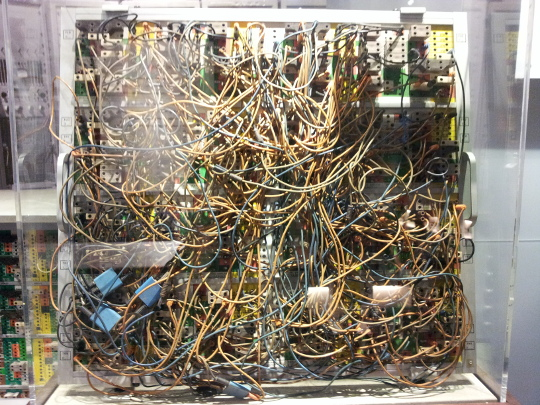

## Better Idea: Rcpp

**Very natural C++ interface to R**

- uses a type registry and some "sugar" to encapsulate and provide better experience to dev
  - c++ operator overloading
  - improved interface hides type conversion, boilerplate code
  - sugar access to R-like functions
- probably reduces mistakes

## A Real Use-Case Filtering on a Valid Region

**Smoothing Time Series (kernel width = 5)**

[video not shown]

## So How Do We Filter?

**Time domain valid region convolution: 1D filtering as the dot product over time**

\[(s*k)=\sum_{n=0}^N \sum_{m=0}^M s[n + m]k[M - m]\]

**This means that 2 signals of length N, we have N multiplies and N-1 adds for each n, performed N times**

\[O(N^2)\]

**Filtering in the Frequency Domain**

- the FFT provides a fast implementation for DFTs, which we will perform on each signal

\[O(N \log N)\]

- convolution in time domain means multiplication in the frequency domain
- now IFFT the product to get back to time domain

## An application of FFTs: Image Registration

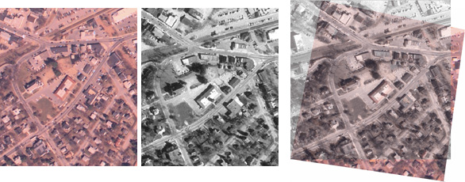

**First two images, aligned**

- typically done with cross-correlation of micro-patches
- followed by warping

## Filter Signal with a Kernel

**Many times, signal length T, kernel length K, shorter than T**

- valid region will be T - K + 1

**Fastest Execution Depends**

- now we have T * K multiplies, T * (K - 1) adds in time domain
- frequency domain, need 2 signals length N = T + K - 1, zeropadded
  - typically extend to good FFT size

**Affected by**

- lengths of signals (changes number of flops)
- memory allocation and movement

## R Builtin

**convolve(signalA, signalB, type='filter')**

## Rcpp: First Steps

**inline directly with cfunction()**

- getting your hands dirty easy but also cumbersome
  - who writes C++ without errors on the first try??

**sourceCpp()**

- source an entire C++ file
  - nice and simple, plus builtin to Rstudio!

**compileAttributes(pathToPackage)**

- turns "sugar" into gold!
  - Knows annotations, uses them to augment/generate wrapper code

## Rcpp skeleton

```r
Rcpp.package.skeleton(name = "anRpackage", list = character(),
    environment = .GlobalEnv, path = ".", force = FALSE,
    code_files = character(), cpp_files = character(),
    example_code = TRUE, attributes = TRUE, module = FALSE,
    author = "Who wrote it",
    maintainer = if(missing( author)) "Who to complain to" else author,
    email = "yourfault@somewhere.net",
    license = "What Licence is it under ?"
    )
```

**Generate a package**

- tweak meta-data, code
- call compileAttributes()

## 1D Filtering in Time Domain

```c
//' Valid region cross-correlation of a vector with another vector.
//' This is equivalent to convolve(x, y, type='filter')
//'
//' @param x first input signal (length(x) >= length(y))
//' @param y second input signal (length(y) < length(x))
//' @return a vector that is of width length(x) - length(y) + 1
// [[Rcpp::export]]
NumericVector ctron_xcorr1(const NumericVector& x, const NumericVector& y)
{

    int iT = x.size();
    int fT = y.size();

    // valid-region cross-correlation output
    NumericVector z(iT - fT + 1, 0.);
    int oT = z.size();

    for (int i = 0; i < oT; ++i)
    {
        for (int j = 0; j < fT; ++j)
        {
            z[i] += x[i + j] * y[j];
        }
    }
    return z;
}
```

## 1D Filtering in Frequency Domain

```c
//' Valid region cross-correlation of a vector with another vector using fftw.
//' This is equivalent to convolve(x, y, type='filter') when corr=TRUE
//'
//' @param x first input signal (length(x) >= length(y))
//' @param y second input signal (length(y) < length(x))
//' @return a vector that is of width length(x) - length(y) + 1
// [[Rcpp::export]]
NumericVector ctron_fftfilt1(const NumericVector& x, const NumericVector& y, bool corr)
{

    int xsz = x.size();
    int ysz = y.size();

    // fft size
    int wide = nextPowerOf2(xsz + ysz - 1);

    // valid-region convolution/cross-correlation size
    int narrow = xsz - ysz + 1;
    NumericVector z(narrow);

    fftw_plan p;

    // Buffers for FFTs
    fftw_complex* xwide =
    (fftw_complex*) fftw_malloc(sizeof(fftw_complex) * wide);
    fftw_complex* ywide =
    (fftw_complex*) fftw_malloc(sizeof(fftw_complex) * wide);
```

## 1D Filtering in Frequency Domain (Cont.)

```c
    int mn = std::min<int>(xsz, ysz);

    // zero out xwide, ywide
    ...

    // copy x into a complex array
    for (int i = 0; i < xsz; ++i)
    {
        ...
    }

    // copy y into a complex array forward or backward?
    if (corr)
    {
        ...
    }
    else
    {
        ...
    }

    fftfilt1(wide, p, xwide, ywide, corr);

    // cleanup
    ...
```

## 1D Filtering in Frequency Domain (the "Workhorse")

```c
// 1D FFT filtering
void fftfilt1(int wide, fftw_plan& p,
          fftw_complex* xwide, fftw_complex* ywide, bool corr)
{

    // FFTs
    p = fftw_plan_dft_1d(wide, xwide, xwide, FFTW_FORWARD, FFTW_ESTIMATE);
    fftw_execute(p);
    fftw_execute_dft(p, ywide, ywide);

    // conj, followed by complex multiply
    for (int i = 0; i < wide; i++)
    {
        ywide[i][1] = -ywide[i][1];
        double xwr = xwide[i][0];
        double xwi = xwide[i][1];
        xwide[i][0] = xwr * ywide[i][0] - xwi * ywide[i][1];
        xwide[i][1] = xwr * ywide[i][1] + xwi * ywide[i][0];
    }

    // IFFT
    p = fftw_plan_dft_1d(wide, xwide, xwide, FFTW_BACKWARD, FFTW_ESTIMATE);
    fftw_execute(p);

}
```

**Generates wrappers**

```c
// This file was generated by Rcpp::compileAttributes
// Generator token: 10BE3573-1514-4C36-9D1C-5A225CD40393

#include <Rcpp.h>

using namespace Rcpp;

// ctron_xcorr1
NumericVector ctron_xcorr1(const NumericVector& x, const NumericVector& y);
RcppExport SEXP convotron_ctron_xcorr1(SEXP xSEXP, SEXP ySEXP) {
BEGIN_RCPP
    Rcpp::RObject __result;
    Rcpp::RNGScope __rngScope;
    Rcpp::traits::input_parameter< const NumericVector& >::type x(xSEXP);
    Rcpp::traits::input_parameter< const NumericVector& >::type y(ySEXP);
    __result = Rcpp::wrap(ctron_xcorr1(x, y));
    return __result;
END_RCPP
}
// ctron_conv1
...
```

## Build

**Using external libs?**

- here fftw3, so create Makevars, Makevars.WIN
  - add PKG_LIBS
  - needs to be all there and if you are installing from a non-standard location, need CXX_FLAGS as well!
- now usual suspects
  - R CMD CHECK convotron
  - R CMD INSTALL convotron

## Results

**A length 3000, B length 300**

```
> A = matrix(runif(3000)*2-1, 60, 50)

> B = matrix(runif(300)*2-1, 60, 5)

> benchmark(loop.convR(A,B), loop.xcorr1(A,B), loop.fftfilt1(A,B), native.xcorr1(A,B), native.fftfilt1(A,B), replications=1000)
                   test replications elapsed relative user.self sys.self user.child sys.child
1      loop.convR(A, B)         1000   1.655    66.20     1.652    0.000          0         0
3   loop.fftfilt1(A, B)         1000   2.166    86.64     2.136    0.024          0         0
2     loop.xcorr1(A, B)         1000   0.297    11.88     0.296    0.000          0         0
5 native.fftfilt1(A, B)         1000   1.772    70.88     1.740    0.028          0         0
4   native.xcorr1(A, B)         1000   0.025     1.00     0.024    0.000          0         0
```

**Native cross-correlation wins**

## Results

```
> A = matrix(runif(30000)*2-1, 6, 5000)

> B = matrix(runif(300)*2-1, 6, 50)

> benchmark(loop.convR(A,B), loop.xcorr1(A,B), loop.fftfilt1(A,B), native.xcorr1(A,B), native.fftfilt1(A,B), replications=1000)
                   test replications elapsed relative user.self sys.self user.child sys.child
1      loop.convR(A, B)         1000   4.245    3.324     4.236    0.000          0         0
3   loop.fftfilt1(A, B)         1000   2.067    1.619     2.060    0.004          0         0
2     loop.xcorr1(A, B)         1000   2.037    1.595     2.036    0.000          0         0
5 native.fftfilt1(A, B)         1000   1.277    1.000     1.272    0.000          0         0
4   native.xcorr1(A, B)         1000   1.405    1.100     1.376    0.024          0         0
```

**Native FFT wins**

## Results

**2D convolution with image A, size 60x50, kernel 5x6**

- Note, there is no conv2() built in to R, this is hand-rolled, but same approach as convolve()

```
> A = matrix(runif(3000)*2-1, 60, 50)

> B = matrix(runif(30)*2-1, 5, 6)

> benchmark(conv2(A,B), ctron_conv2mx(A, B), replications=1000)
                 test replications elapsed relative user.self sys.self user.child sys.child
1         conv2(A, B)         1000   0.340    4.928     0.340        0          0         0
2 ctron_conv2mx(A, B)         1000   0.069    1.000     0.068        0          0         0
```

**Native time domain 2D conv wins**

## Phew, deep breath…. Okay, Java time

**Search System**

- Inverted index, makes searching for text fast
  - Constant time lookup from word to documents
  - If you are scanning, its going to be linear traversal of all docs
- Also provides powerful, expressive grammars

**So I thought…**

- It would be fun if we could index a frame in R and search over it
- Lucene API in Java could easily make this happen
- rJava is a fun way to spend an afternoon

## But How?

**Achtung! Lucene's API is a bit thorny**

- I could've picked an easier library, but, the devil you know…

**General Flow for Indexing**

- Create an Analyzer (for tokenization of your doc)
- Create an IndexWriter
- For each column in our frame we want to index
  - Tell lucene how we want it stored in a Document, and add

**General Flow for Searching**

- Create an IndexSearcher and Query
  - A lot of times, we want a QueryParser to help
- Get results back and "hydrate"

## First steps

**Package or stand-alone**

- I recommend package!
  - You can use package.skeleton(), then tweak

**Need Java installed first**

- Rjava will embed, talk to JVM

**Grab your dependency jars**

- Java archive files we want in our "classpath"

## Let's Assume you are making a directory

```
dpressel@dpressel:~/dev/work/lucifR$ ls -R
.:
DESCRIPTION  inst  NAMESPACE  R  README.md

./inst:
java

./inst/java:
lucene-analyzers-common-5.3.1.jar  lucene-core-5.3.1.jar  lucene-queryparser-5.3.1.jar

./R:
lucifR.index.R     lucifR.newAnalyzer.R  lucifR.newSearcher.R  lucifR.search.R  onLoad.R
lucifR-internal.R  lucifR.newQuery.R     lucifR.queryParser.R  lucifR.tokr.R
```

## On load, package initialization

```r
onLoad <-
function(libname, pkgname) {
        .jpackage(pkgname, lib.loc=libname)
}
```

**Finds your inst/java directory, add classpath dependencies automatically**

## Ok, let's code

**To do lucene stuff, we need an analyzer**

```r
# Default our argument to the path style name for the Java class
lucifR.newAnalyzer <-
function(byName="org/apache/lucene/analysis/standard/StandardAnalyzer") {
  # J accesses the class
  StandardAnalyzer = J(byName);

  # new(X) allocates an X
  analyzer = new(StandardAnalyzer);
}
```

## Next: tokenize

```r
lucifR.tokr <-
function(an, str) {
  CharTermAttribute = J("org/apache/lucene/analysis/tokenattributes/CharTermAttribute");
  # We call class methods like this!
  ts = an$tokenStream("dontcare", str);
  charTermAttribute = ts$addAttribute(CharTermAttribute$class);

  ts$reset();
  toks = c();

  # Traverse tokens
  while (ts$incrementToken()) {
    # And get the values out and put them in a list
    rstr = as.character(charTermAttribute$toString())
    toks = c(toks, rstr);
  }

  ts$end();
  ts$close();
  return(toks)
}
```

## So far…

```r
require(lucifR)
an = lucifR.newAnalyzer()
lucifR.tokr(an, "I like cats.   They are pretty awesome!")
```

```
## [1] "i"       "like"    "cats"    "pretty"  "awesome"
```

**Right??**

- Ok, on to the hard stuff!
- Notice hard part is navigating Lucene, not rJava!

## Indexing a Frame in Lucene

```r
lucifR.index <-
function(aframe, dirname, fnames=names(F), cb=NULL) {
  ...
  # Just to show how to use .jnew instead of new(X)
  jfs = .jnew("java/io/File", dirname)
  jpath = jfs$toPath()
  iwc = new(IndexWriterConfig, analyzer)

  iwc$setOpenMode(IndexWriterConfig$OpenMode$CREATE);
  jdir = FSDirectory$open(jpath);
  writer = new(IndexWriter, jdir, iwc);

  # Go through all rows in a frame indexing any requested fname (column)
  invisible(sapply(1:nrow(aframe), function(i) {

    doc = new(Document);
    for (name in fnames) {
      val = aframe[i,][[name]]
      tf = new(TextField, name, as.character(val), Field$Store$YES);
      doc$add(tf);
    }
    doc$add(new(IntField, "docid", i, Field$Store$YES));
    writer$addDocument(doc);
    ...
  }));
  writer$close();
}
```

## Searching an Index

```r
lucifR.search <-
function(aframe, searcher, q, limit=10) {

  # Rjava will need this to be the base class not derived, otherwise the method wont be found
  qq = .jcast(q, new.class="org/apache/lucene/search/Query", check=TRUE)

  # Explicitly give the sig of this method, passing cast query and explicitly coerce limit to int
  top = .jcall(searcher, "Lorg/apache/lucene/search/TopDocs;", "search", qq, as.integer(limit))
  hits = top$scoreDocs

  # Initialize an empty table with same names as aframe, but also with a score
  df = read.table(text="", col.names=c(names(aframe), "score"))

  for (hit in hits) {
    doc = searcher$doc(hit$doc);

    # Get the row back in the frame -- we stored this in the index
    docid = as.integer(doc$get("docid"));

    # bind the score to the aframe row, and append that into df
    df <- rbind(df, cbind(aframe[docid,], hit$score))
  }
  return (df)
}
```

## Finally, Profit!

```r
require(lucifR)
p = 'Apple-Twitter-Sentiment-DFE.csv'
F = read.csv(p)
lucifR.index(F, 'apple-idx', c('text'))
searcher = lucifR.newSearcher('apple-idx')
qp = lucifR.queryParser(c('text'), lucifR.newAnalyzer())
q = lucifR.newQuery(qp, 'garbage OR crap OR "stopped working"')
hits = lucifR.search(F, searcher, q)
print(hits$text[1:5])
```

```
## [1] @SuzanneBoyd @Apple it stopped working? I would be screaming. I'm getting mine 12/24.
## [2] Happy Monday! My camera on my fancy @Apple #iPhone6Plus suddenly stopped working this weekend, so instead - I meme. http://t.co/ktImoxWESr
## [3] Happy Monday! My camera on my fancy @Apple #iPhone6Plus suddenly stopped working this weekend, so instead - I meme. http://t.co/XdySgcxUuv
## [4] Happy Monday! My camera on my fancy @Apple #iPhone6Plus suddenly stopped working this weekend, so instead - I meme. http://t.co/Mb067jv5SD
## [5] Happy Monday! My camera on my fancy @Apple #iPhone6Plus suddenly stopped working this weekend, so instead - I meme. http://t.co/lp9KPujmPg
## 3217 Levels: 0144 : #Sick : Being sick has a perk. Catching up on a million shows with @apple TV. ...
```

## A Few More Notes About rJava

**In the code, I demonstrate the more low level API and reflection**

- Reflected code is almost like Java!
- Reflected methods are slower avoid where speed is a concern
- Sometimes, reflection can goof up giving us the wrong thing in the sig
  - Use .jcast and .jcall to handle this like a boss…

## In Summary

**R is "Good at" Accessing Other Languages**

- Your pain and suffering should be minimal!

**Good Reasons to Access Other Languages**

- Speed
- Flexibility
- Boredom